# Esercizi Prima Parte

Stefano Dalla Bona

## Esercizio 1 – Consegna (1)

### *1.1*

Si crei un vettore $x$ composto da tutti i numeri naturali che vanno da 1 a 10. Si individuino altri due metodi alternativi per creare lo stesso vettore.

### *1.2*

Si calcoli la media geometrica di $x$. La formula per il calcolo della media geometrica è ([Link Wikipedia](https://en.wikipedia.org/wiki/Geometric_mean)):

$$\left(\prod_{i=1}^{n} x_{i}\right)^{\frac{1}{n}} = \sqrt[n]{x_{1} x_{2} \cdots x_{n}}$$

## Esercizio 1 – Consegna (2)

### *1.3*

Utilizzare la funzione `function` per creare una nuova funzione in *R*, attraverso la quale calcolare la media geometrica senza dover riscrivere ogni volta la formula (`?function` per ottenere un suggerimento su come creare una funzione).

## Esercizio 1 – Risoluzione

### 1.1 Creazione del vettore

```r
x <- 1:10  # Creazione del vettore
x <- seq(1, 10, 1)  # Alternativa 1
x <- sort(sample(1:10))  # Alternativa 2 (esistono altre alternative)
```

### 1.2 Calcolo della media geometrica

```r
prod(x)^(1/length(x))  # Media geometrica
```

```
[1] 4.528729
```

```r
exp(mean(log(x)))  # Risoluzione alternativa
```

```
[1] 4.528729
```

### 1.3 Creazione della funzione

```r
geomMean <- function(vect) {
  prod(vect)^(1/length(vect))}

geomMean(x)
```

```
[1] 4.528729
```

## Esercizio 2 – Consegna (1)

### *1.1*

Si crei un vettore $QI$ composto da 100 valori estratti casualmente da una distribuzione $N \sim \mu = 100, \sigma = 15$. Si utilizzi la funzione `rnorm` (`?rnorm` per ottenere un suggerimento su come utilizzare la funzione).

### *1.2*

Si calcolino la media $M$ e la Deviazione Standard $SD$, senza utilizzare le relative funzioni in *R*.

## Esercizio 2 – Consegna (2)

### *1.3*

Si standardizzino i punteggi ottenuti con la formula:

$$z = \frac{x_1 - \mu}{\sigma}$$

### *1.4*

Si calcolino la media $M$ e la Deviazione Standard $SD$ dei punteggi standardizzati, utilizzando le relative funzioni in *R*. Cosa possono rappresentare questi punteggi?

## Esercizio 2 – Risoluzione (1)

### 1.1 Creazione del vettore

```r
QI <- rnorm(100,  # Numero di estrazioni
            100,  # Media della popolazione
            15)   # Deviazione Standard della popolazione
```

### 1.2 Calcolo degli indici

```r
sum(QI) / length(QI)  # Media
```

```
[1] 99.11521
```

```r
s <- (QI - sum(QI) / length(QI))^2  # Scarti dalla media al quadrato

sqrt(sum(s / length(QI)))  # Deviazione standard
```

```
[1] 14.30823
```

## Esercizio 2 – Risoluzione (2)

### 1.3 Standardizzazione

```r
QI2 <- (QI - mean(QI)) / sd(QI)  # Punteggi standardizzati
```

### 1.4 Calcolo degli indici

```r
round(mean(QI2), 2)  # Media
```

```
[1] 0
```

```r
sd(QI2)  # Deviazione Standard
```

```
[1] 1
```

Probabilmente il primo vettore $QI$ rappresenta i risultati di un test d’intelligenza, mentre il secondo vettore $QI2$ rappresenta i risultati di un test d’intelligenza standardizzati.

## Esercizio 3 – Consegna (1)

### *3.1*

Si crei un vettore $x$ e si assegni ad esso i numeri 1 e 2 con la funzione di concatenazione. Si crei un secondo vettore $y$ e si assegni ad esso i numeri 1 e 2 con la funzione di concatenazione. Si calcoli la correlazione tra i due vettori e si mostri graficamente la relazione tra i due vettori (si provi anche, prima di eseguire la funzione di correlazione, ad anticipare che risultato ci potremmo aspettare).

## Esercizio 3 – Consegna (2)

### *3.2*

Si aggiunga a ciascuno dei vettori $x$ e $y$ un terzo numero che permetta di ottenere una correlazione di 0.5 tra i due vettori e si riesegua il calcolo della correlazione e la rappresentazione grafica.

## Esercizio 3 – Risoluzione (1)

### 3.1 Correlazione tra i vettori

```r
x <- 1:2  # Vettore X
c(1,2) -> y  # Vettore Y
cor(x, y)  # Calcolo della correlazione
```

```
[1] 1
```

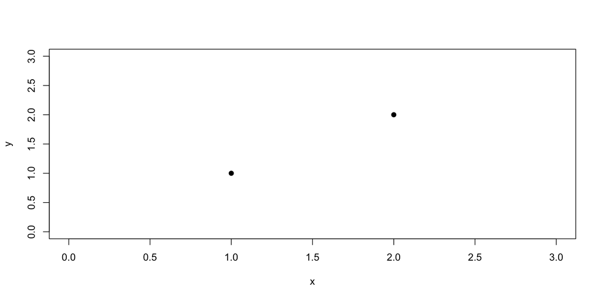

```r
# Grafico della relazione
plot(x, y, pch=19, xlim=c(0, 3), ylim=c(0, 3), xlab="x", ylab="y")
```

## Esercizio 3 – Risoluzione (2)

### 3.1 Correlazione tra i vettori modificati

```r
x[3] <- 2  # Aggiungere un valore a X...
y[3] <- 1  # Aggiungere un valore a Y...
cor(x, y)  # Calcolo della correlazione, tale per cui diventa 0.5
```

```
[1] 0.5
```

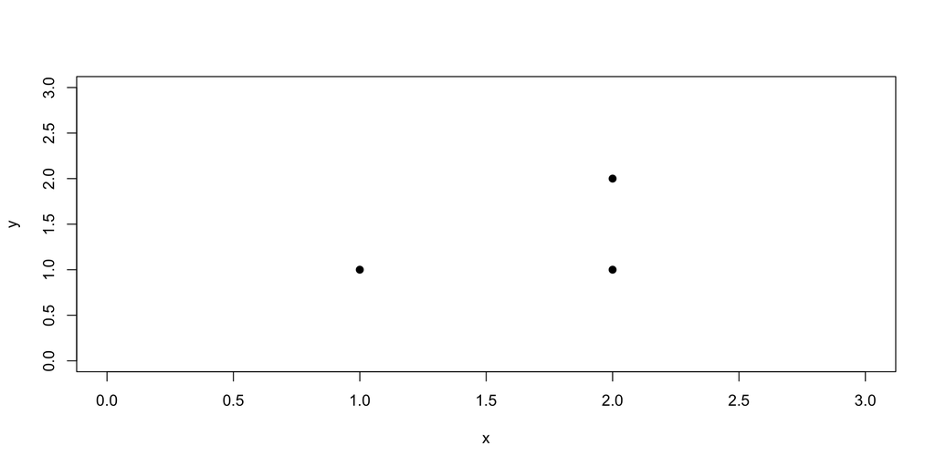

```r
# Grafico della relazione
plot(x, y, pch=19, xlim=c(0, 3), ylim=c(0, 3), xlab="x", ylab="y")
```

## Esercizio 3 – Risoluzione (3)

### Visualizzazione grafica con `ggplot2`

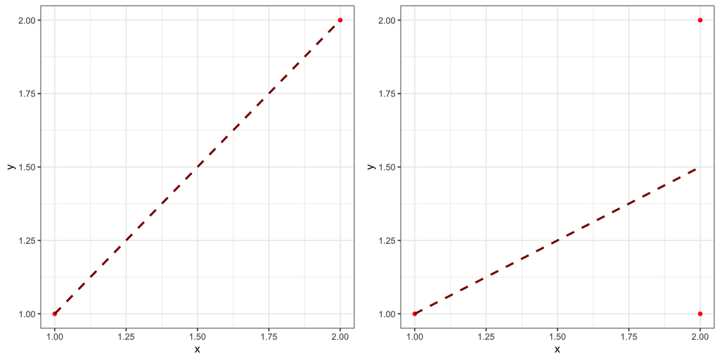